# ht5

Dmitriy Tsimokha

07.12.20

**Turn the dark theme if you are reading it at night! (button with sun at the left)**

```r
library(foreign); library(knitr); library(ggplot2); library(kableExtra)
library(jtools); library(memisc); library(sjPlot); library(ggstance)
library(broom.mixed); library(stargazer); library(ggthemr)
df <- read.spss("dataht5.sav", use.value.labels = T, to.data.frame = T)
df <- na.omit(df[c("happy", "gndr", "inwyys", "yrbrn", "sclmeet")])
```

# 1. Visualizing distributions

[Really nice graphing guide!](https://cedricscherer.netlify.app/2019/08/05/a-ggplot2-tutorial-for-beautiful-plotting-in-r/)

[Even nicer amount of themes for plotting!](https://rfortherestofus.com/2019/08/themes-to-improve-your-ggplot-figures/)

*I just can’t stop choosing between different themes, help*

## Happy (dependent variable)

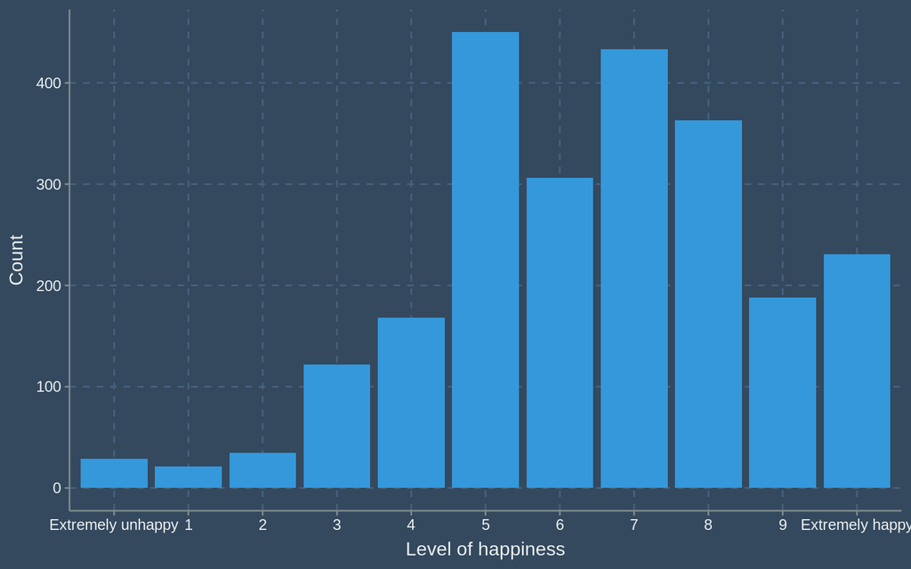

```r
g <- ggplot(df, aes(x = happy))
g + geom_bar(stat = 'count') +
  labs(x = "Level of happiness", y = "Count")
```

## Gender

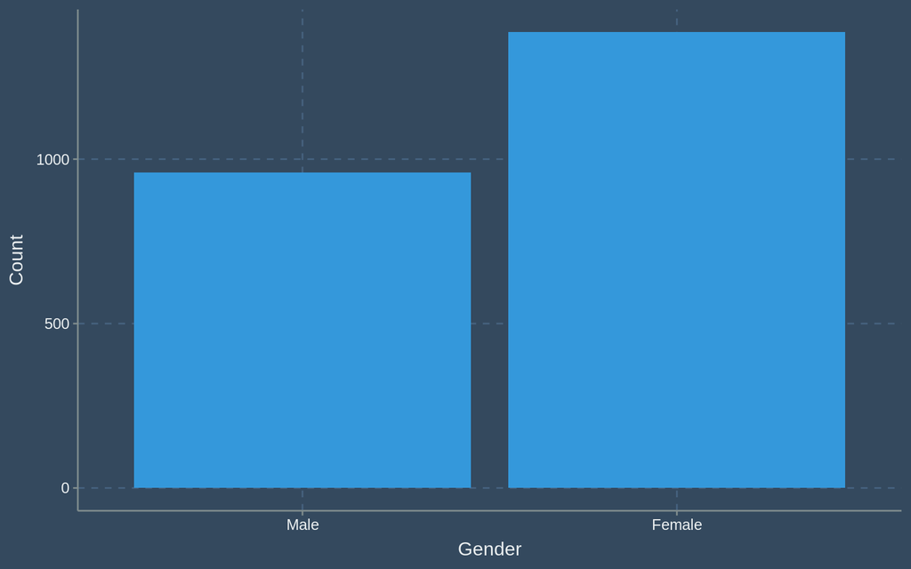

```r
g <- ggplot(df, aes(x = gndr))
g + geom_bar(stat = 'count') +
  labs(x = "Gender", y = "Count")
```

## Age

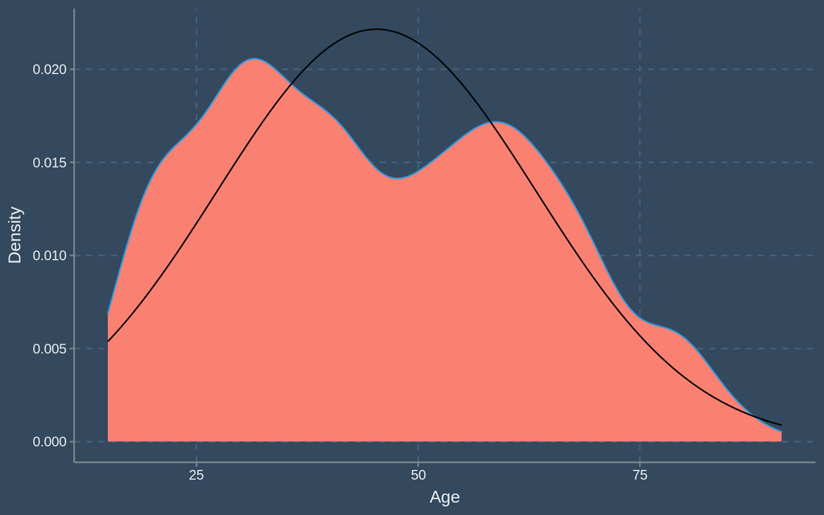

```r
df$age <- as.numeric(levels(df$inwyys))[df$inwyys] - as.numeric(levels(df$yrbrn))[df$yrbrn]
ggplot(df, aes(x = age)) +
  geom_density(fill = "salmon", stat = 'density') +
  stat_function(fun = dnorm, args = list(mean = mean(df$age), sd = sd(df$age))) +
  labs(x = "Age", y = "Density")
```

Distrubution of **age** have two peakes at ~30 and at ~60 but still can be considered as close to equal (if we really want to).

## Meeting with friends and colleagues frequency

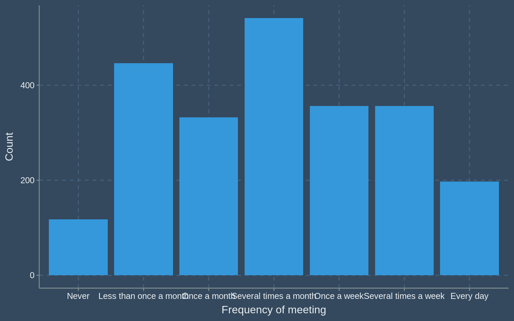

```r
ggplot(df, aes(x = sclmeet)) +
  geom_bar(stat = 'count') +
  labs(x = "Frequency of meeting", y = "Count")
```

Too can be considered as normal distribution (*if look from far distance*).

# 2. Simple model with control variables (age & gender)

[Great visualization tool for regression!](https://cran.r-project.org/web/packages/jtools/vignettes/summ.html)

```r
model1 <- lm(data = df, as.numeric(happy) ~ age + gndr)
tab_model(model1)
```

|  | as.numeric(happy) |  |  |
| --- | --- | --- | --- |
| Predictors | Estimates | CI | p |
| (Intercept) | 8.25 | 8.00 – 8.49 | **<0.001** |
| age | -0.02 | -0.02 – -0.01 | **<0.001** |
| gndr [Female] | -0.13 | -0.32 – 0.05 | 0.145 |
| Observations | 2346 |  |  |
| R<sup>2</sup> / R<sup>2</sup> adjusted | 0.019 / 0.018 |  |  |

And **gender** is not significant! It can be seen not only by p-value larger than 0.05, but also that confident interval includes **0**.

Even though **age** is significant it still causes very small effect at first glance - but if we consider that age don’t start from 0 and difference can be 50 or more years difference in effect can be really large (per -0.02 for each year).

*Looks like the older we get the less happier we feel :(*

# 3. More complex model with meeting frequency

```r
model2 <- lm(data = df, as.numeric(happy) ~ age + gndr + sclmeet)
# https://strengejacke.github.io/sjPlot/articles/tab_model_estimates.html
tab_model(model2)
```

|  | as.numeric(happy) |  |  |
| --- | --- | --- | --- |
| Predictors | Estimates | CI | p |
| (Intercept) | 7.15 | 6.67 – 7.64 | **<0.001** |
| age | -0.01 | -0.02 – -0.01 | **<0.001** |
| gndr [Female] | -0.14 | -0.32 – 0.04 | 0.122 |
| sclmeet [Less than once a month] | 0.59 | 0.15 – 1.02 | **0.008** |
| sclmeet [Once a month] | 0.80 | 0.34 – 1.25 | **0.001** |
| sclmeet [Several times a month] | 0.94 | 0.51 – 1.37 | **<0.001** |
| sclmeet [Once a week] | 1.19 | 0.74 – 1.64 | **<0.001** |
| sclmeet [Several times a week] | 1.20 | 0.74 – 1.66 | **<0.001** |
| sclmeet [Every day] | 1.20 | 0.70 – 1.70 | **<0.001** |
| Observations | 2346 |  |  |
| R<sup>2</sup> / R<sup>2</sup> adjusted | 0.038 / 0.035 |  |  |

The second model is more complex and include **frequency of meeting** with friends and colleagues: - **gender** again is not significant! - **frequency of meeting** is significant and have **strong positive** effect on level of happiness!

```r
stargazer(anova(model1, model2), type = "html", title="ANoVA", intercept.bottom = FALSE,
          single.row = TRUE, align=TRUE, ci=TRUE, ci.level=0.95, no.space=TRUE)
```

**ANoVA**

| Statistic | N | Mean | St. Dev. | Min | Pctl(25) | Pctl(75) | Max |
| --- | --- | --- | --- | --- | --- | --- | --- |
| Res.Df | 2 | 2,340.000 | 4.243 | 2,337 | 2,338.5 | 2,341.5 | 2,343 |
| RSS | 2 | 10,810.390 | 147.594 | 10,706.020 | 10,758.210 | 10,862.570 | 10,914.750 |
| Df | 1 | 6.000 |  | 6.000 | 6.000 | 6.000 | 6.000 |
| Sum of Sq | 1 | 208.730 |  | 208.730 | 208.730 | 208.730 | 208.730 |
| F | 1 | 7.594 |  | 7.594 | 7.594 | 7.594 | 7.594 |
| Pr(> F) | 1 | 0.00000 |  | 0.00000 | 0.00000 | 0.00000 | 0.00000 |

The **model2** with **frequency of meeting** is significantly better than *model1*: lower RSS shows that.

```r
tab_model(model1, model2)
```

|  | as.numeric(happy) |  |  | as.numeric(happy) |  |  |
| --- | --- | --- | --- | --- | --- | --- |
| Predictors | Estimates | CI | p | Estimates | CI | p |
| (Intercept) | 8.25 | 8.00 – 8.49 | **<0.001** | 7.15 | 6.67 – 7.64 | **<0.001** |
| age | -0.02 | -0.02 – -0.01 | **<0.001** | -0.01 | -0.02 – -0.01 | **<0.001** |
| gndr [Female] | -0.13 | -0.32 – 0.05 | 0.145 | -0.14 | -0.32 – 0.04 | 0.122 |
| sclmeet [Less than once a month] |  |  |  | 0.59 | 0.15 – 1.02 | **0.008** |
| sclmeet [Once a month] |  |  |  | 0.80 | 0.34 – 1.25 | **0.001** |
| sclmeet [Several times a month] |  |  |  | 0.94 | 0.51 – 1.37 | **<0.001** |
| sclmeet [Once a week] |  |  |  | 1.19 | 0.74 – 1.64 | **<0.001** |
| sclmeet [Several times a week] |  |  |  | 1.20 | 0.74 – 1.66 | **<0.001** |
| sclmeet [Every day] |  |  |  | 1.20 | 0.70 – 1.70 | **<0.001** |
| Observations | 2346 |  |  | 2346 |  |  |
| R<sup>2</sup> / R<sup>2</sup> adjusted | 0.019 / 0.018 |  |  | 0.038 / 0.035 |  |  |

Still, each model describes only up to 0.04 variance max at the best case and that’s too bad!

# 4. Interpretation

## Assumptions

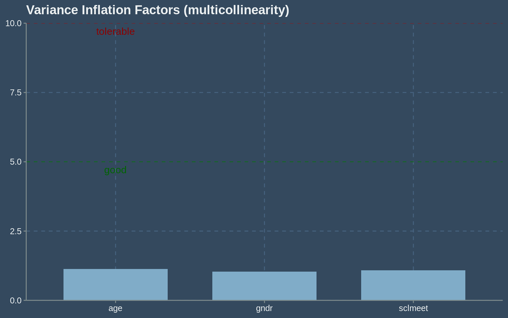

```r
plot_model(model2, type = "diag")[[1]]
```

We don’t have any multicollinearity!

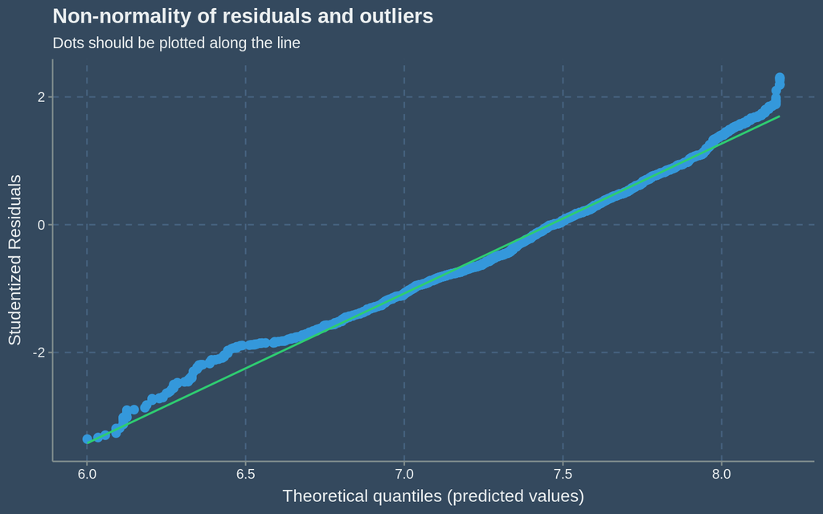

```r
plot_model(model2, type = "diag")[[2]]
```

And even residuals distributed normally and there are no major outliers!

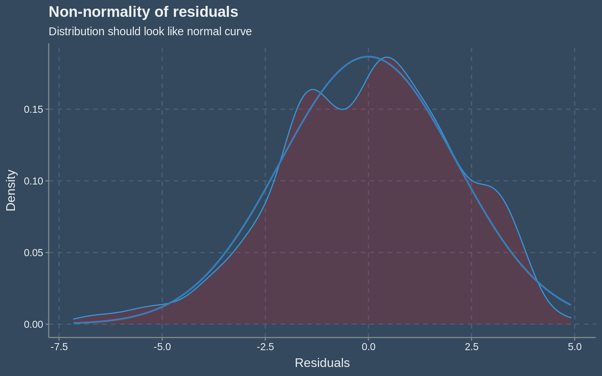

```r
plot_model(model2, type = "diag")[[3]]
```

Here again - residuals at the best shape and very nicely fits under the normal distribution line.

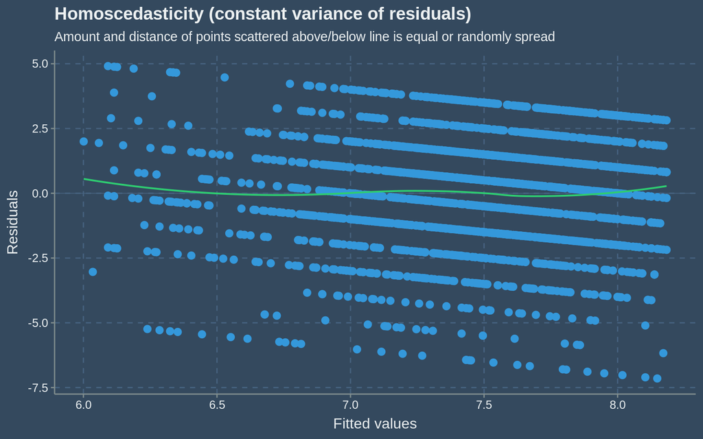

```r
plot_model(model2, type = "diag")[[4]]
```

And here the baddest picture - homoscedasticity. Looks as bad as
$$R^2$$
of our models.

# 5. Visualization of the better model

*shine bright!*

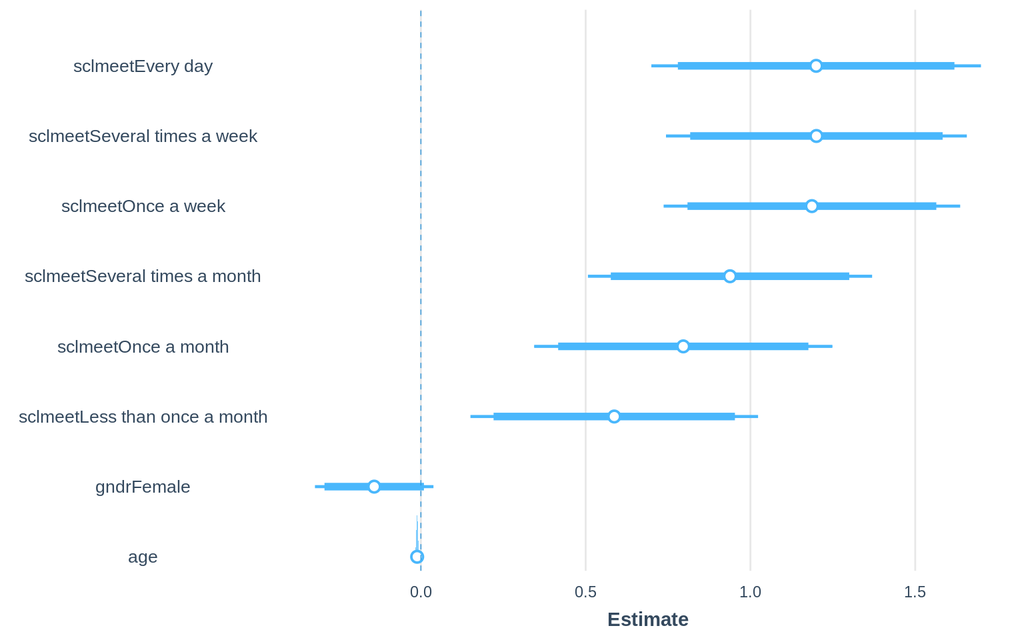

```r
plot_summs(model2, plot.distributions = TRUE, inner_ci_level = .9)
```

Again, here can be seen coefficients with confidence intervals of the best (second) model: - **age** is nearly on the line - **gender** crosses the line with it’s confidence interval - and for different levels of **meeting frequency** everything great!

## Effects

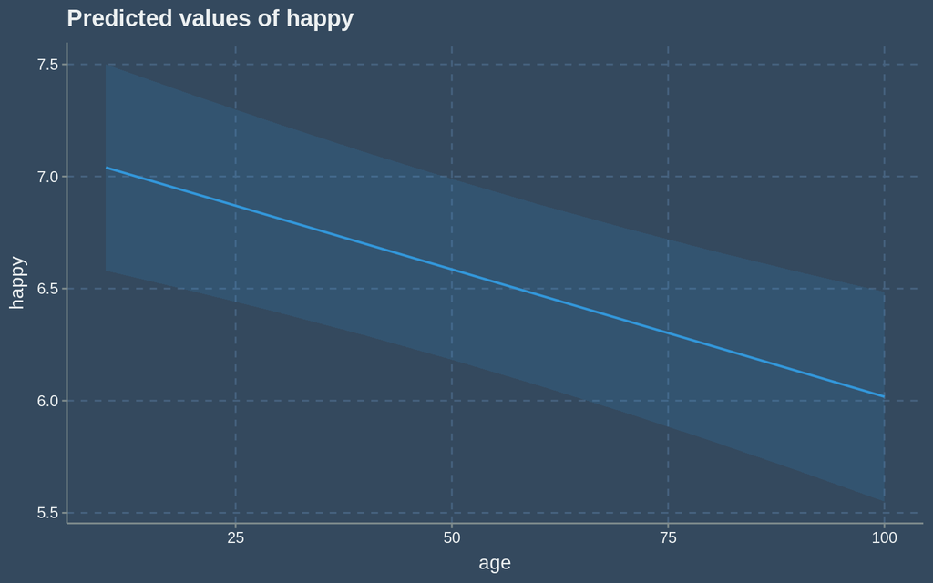

```r
plot_model(model2, type = "pred")[[1]]
```

**Age** has significant negative effect and with greater age level of happiness expected to lower.

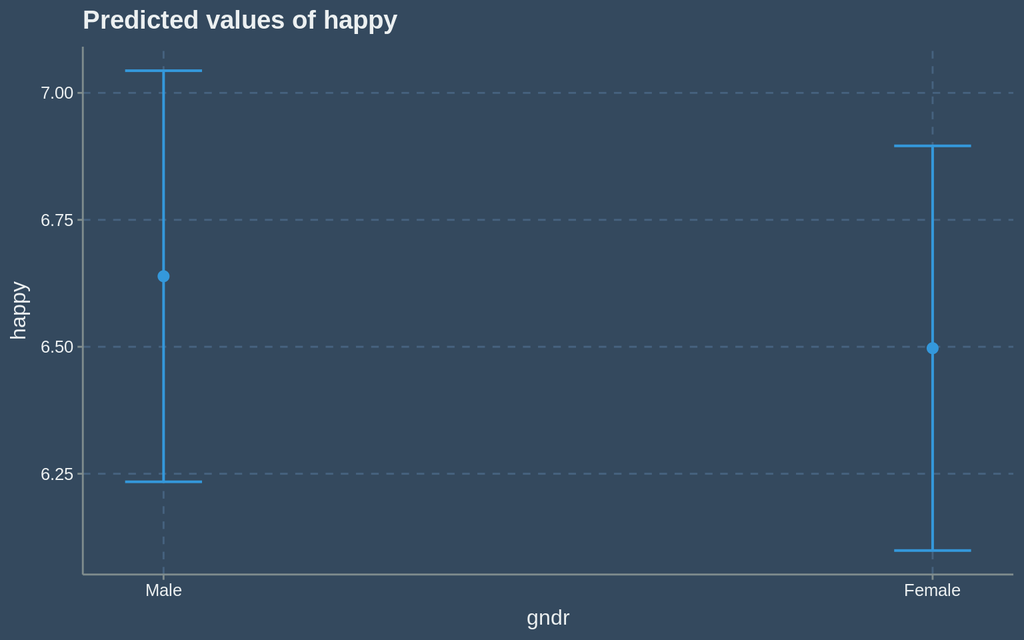

```r
plot_model(model2, type = "pred")[[2]]
```

**Gender** is not significant so that picture can be scipped.

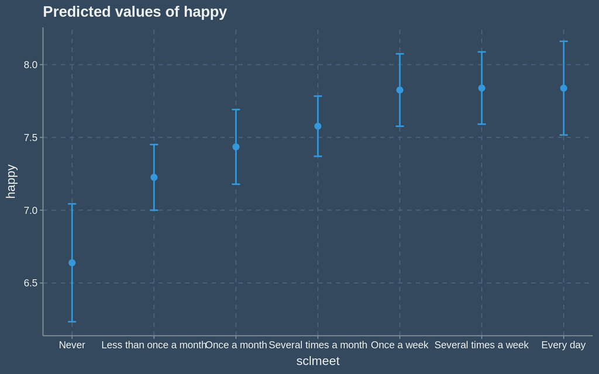

```r
plot_model(model2, type = "pred")[[3]]
```

And **level of happiness** significantly affected by **meeting frequency** with positive direction!

# Summary

It does not matter what gender are you - just spend time with your friends more while you are young and **be happy**!